# M3 Lab

Nuo Wei

due 10/23/2022

```r
library(tidyverse)
load("acupuncture_data_reduced (1).RData", verbose=TRUE)
```

```
## Loading objects:
##   data
```

```r
acudata<- data
acudata
```

| id | age | sex | migraine | chronicity | acupuncturist | practice_id | group | pk1 | pk2 | pk5 | f1 | f2 | f5 |
| --- | --- | --- | --- | --- | --- | --- | --- | --- | --- | --- | --- | --- | --- |
| 100 | 47 | 1 | 1 | 35 | 12 | 35 | 1 | 10.75000 | NA | NA | 8.00 | 0.00 | 0.00 |
| 101 | 52 | 1 | 1 | 8 | 12 | 35 | 0 | 9.50000 | NA | NA | 4.00 | 0.00 | 0.00 |
| 104 | 32 | 1 | 1 | 14 | 12 | 35 | 0 | 16.00000 | NA | 15.33333 | 12.00 | 0.00 | 13.33 |
| 105 | 53 | 1 | 1 | 10 | 9 | 25 | 0 | 32.50000 | 44.000000 | NA | 21.00 | 18.00 | 0.00 |
| 108 | 56 | 1 | 1 | 40 | 9 | 25 | 0 | 16.50000 | 17.500000 | 23.25000 | 14.00 | 19.00 | 15.00 |
| 112 | 45 | 1 | 1 | 27 | 9 | 25 | 1 | 9.25000 | 4.750000 | 6.25000 | 15.00 | 8.00 | 13.00 |
| 113 | 45 | 1 | 1 | 30 | 9 | 25 | 1 | 42.50000 | 34.500000 | 51.25000 | 25.00 | 24.00 | 27.00 |
| 114 | 49 | 1 | 1 | 49 | 9 | 25 | 1 | 24.25000 | 16.250000 | 25.25000 | 14.00 | 11.00 | 13.00 |
| 126 | 47 | 1 | 1 | 42 | 5 | 28 | 0 | 21.00000 | 18.500000 | 15.25000 | 11.00 | 10.00 | 10.00 |
| 130 | 46 | 1 | 1 | 3 | 7 | 15 | 1 | 21.75000 | 2.000000 | 1.00000 | 11.00 | 2.00 | 2.00 |

[output cut: 391 more lines]

# Part 0

```r
acudata <- acudata %>% drop_na(pk1,pk2) %>% mutate(change_pk1_pk2 = pk1 - pk2)

#acudata

acudata <- acudata %>% mutate(con_acu_group = factor(group, levels = c(0,1), labels = c("Control", "Acupuncture treatment")))

acudata
```

| id | age | sex | migraine | chronicity | acupuncturist | practice_id | group | pk1 | pk2 | pk5 | f1 | f2 | f5 | change_pk1_pk2 | con_acu_group |
| --- | --- | --- | --- | --- | --- | --- | --- | --- | --- | --- | --- | --- | --- | --- | --- |
| 105 | 53 | 1 | 1 | 10 | 9 | 25 | 0 | 32.50 | 44.000000 | NA | 21.00 | 18.00 | 0.0 | -11.500000 | Control |
| 108 | 56 | 1 | 1 | 40 | 9 | 25 | 0 | 16.50 | 17.500000 | 23.25000 | 14.00 | 19.00 | 15.0 | -1.000000 | Control |
| 112 | 45 | 1 | 1 | 27 | 9 | 25 | 1 | 9.25 | 4.750000 | 6.25000 | 15.00 | 8.00 | 13.0 | 4.500000 | Acupuncture treatment |
| 113 | 45 | 1 | 1 | 30 | 9 | 25 | 1 | 42.50 | 34.500000 | 51.25000 | 25.00 | 24.00 | 27.0 | 8.000000 | Acupuncture treatment |
| 114 | 49 | 1 | 1 | 49 | 9 | 25 | 1 | 24.25 | 16.250000 | 25.25000 | 14.00 | 11.00 | 13.0 | 8.000000 | Acupuncture treatment |
| 126 | 47 | 1 | 1 | 42 | 5 | 28 | 0 | 21.00 | 18.500000 | 15.25000 | 11.00 | 10.00 | 10.0 | 2.500000 | Control |
| 130 | 46 | 1 | 1 | 3 | 7 | 15 | 1 | 21.75 | 2.000000 | 1.00000 | 11.00 | 2.00 | 2.0 | 19.750000 | Acupuncture treatment |
| 131 | 64 | 1 | 1 | 23 | 7 | 15 | 1 | 14.50 | 20.000000 | 2.50000 | 6.00 | 10.00 | 2.0 | -5.500000 | Acupuncture treatment |
| 135 | 59 | 1 | 1 | 40 | 7 | 15 | 0 | 40.50 | 37.250000 | 28.75000 | 24.00 | 23.00 | 22.0 | 3.250000 | Control |
| 137 | 53 | 1 | 1 | 32 | 7 | 15 | 1 | 11.75 | 11.250000 | 13.50000 | 8.00 | 8.00 | 9.0 | 0.500000 | Acupuncture treatment |

[output cut: 316 more lines]

# Part 1

## Descriptives

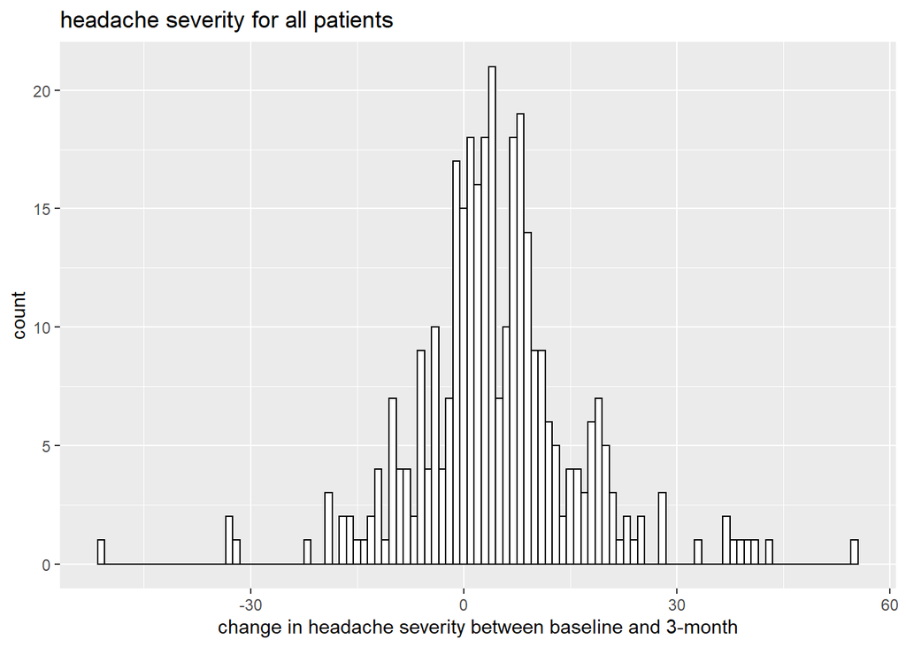

```r
ggplot(acudata, aes(x=change_pk1_pk2))+
  geom_histogram(binwidth = 1, color="black", fill="white") +
  ggtitle("headache severity for all patients")+
  xlab("change in headache severity between baseline and 3-month")
```

```r
acudata %>% drop_na(change_pk1_pk2) %>%
  summarize(n = n(),
            mean = mean(change_pk1_pk2),
            SD = sd(change_pk1_pk2),
            median = median(change_pk1_pk2),
            IQR = IQR(change_pk1_pk2),
            min = min(change_pk1_pk2),
            max = max(change_pk1_pk2))
```

| n | mean | SD | median | IQR | min | max |
| --- | --- | --- | --- | --- | --- | --- |
| 326 | 4.714724 | 11.72555 | 4 | 10.4375 | -50.75 | 55.5 |

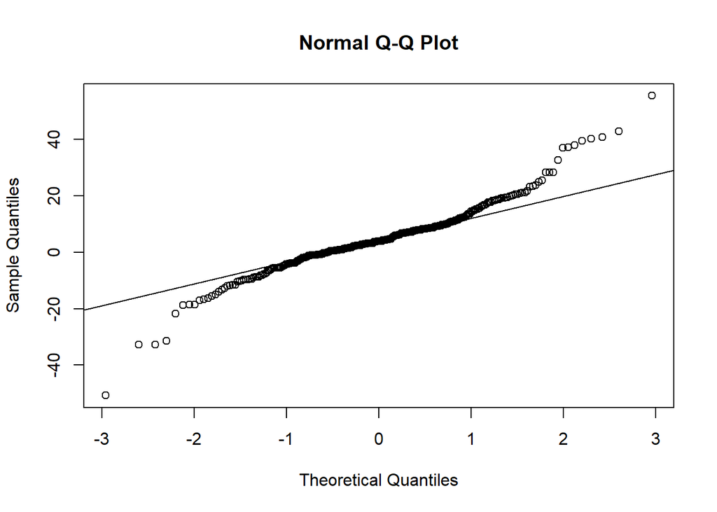

```r
qqnorm(acudata$change_pk1_pk2)
qqline(acudata$change_pk1_pk2)
```

For the Q-Q plot, the majority of plots fall roughly along the diagonal line from Theoretical quantiles -1 to 1. When the theoretical quantiles are greater than 1 and less than -1, the distribution start to rise up or fall down and get further and further away from the diagonal line.

## Paired t test

```r
#0.01 significance level

#H_0: (equal 0)change in headache severity (from baseline to 3 months) for patients with chronic headache for all groups
#H_1: (not equal 0)no change in headache severity (from baseline to 3 months) for patients with chronic headache for all groups

#Condition: simple random sample and n>30

t.test(acudata$change_pk1_pk2,
       alternative = "two.sided",
       mu = 0,
       conf.level = 0.99)
```

```
##
##  One Sample t-test
##
## data:  acudata$change_pk1_pk2
## t = 7.2599, df = 325, p-value = 2.877e-12
## alternative hypothesis: true mean is not equal to 0
## 99 percent confidence interval:
##  3.032054 6.397393
## sample estimates:
## mean of x
##  4.714724
```

```r
#t = 7.2599, df = 325, p-value = 2.877e-12

#alternative hypothesis: true mean is not equal to 0

#99 percent confidence interval: 3.032054 6.397393

#the value of the test statistic from this sample
7.2599
```

```
## [1] 7.2599
```

```r
#the p-value
2.877e-12
```

```
## [1] 2.877e-12
```

```r
#reject H0 (p-value < significance level)

#We have strong evidence that the change in headache severity for patients is not 0.

#we have 99% confident interval that headache frequency decrease between 3.032054 and 6.397393 on average.
```

## Signed rank test

```r
#0.01 significance level

#H_0: (equal 0)median of change in headache severity (from baseline to 3 months) for patients with chronic headache for all groups
#H_1: (not equal 0)median of no change in headache severity (from baseline to 3 months) for patients with chronic headache for all groups

#conditions: simple random sample and symmetric distribution

wilcox.test(acudata$change_pk1_pk2,
            alternative = "two.sided",
            mu = 0,
            conf.level = 0.99,
            correct = FALSE)
```

```
##
##  Wilcoxon signed rank test
##
## data:  acudata$change_pk1_pk2
## V = 39501, p-value = 5.798e-15
## alternative hypothesis: true location is not equal to 0
```

```r
#the p-value
5.798e-15
```

```
## [1] 5.798e-15
```

```r
#reject H0 (p-value < significance level)

#We have strong evidence that the median of change in headache severity for patients is not 0.
```

## Summary of part 1

From the part 1, we can find that change in headache severity for patients is not 0 by paired t test, and the median of change in headache severity for patients is not 0 by signed rank test.

# Part 2

## Descriptives

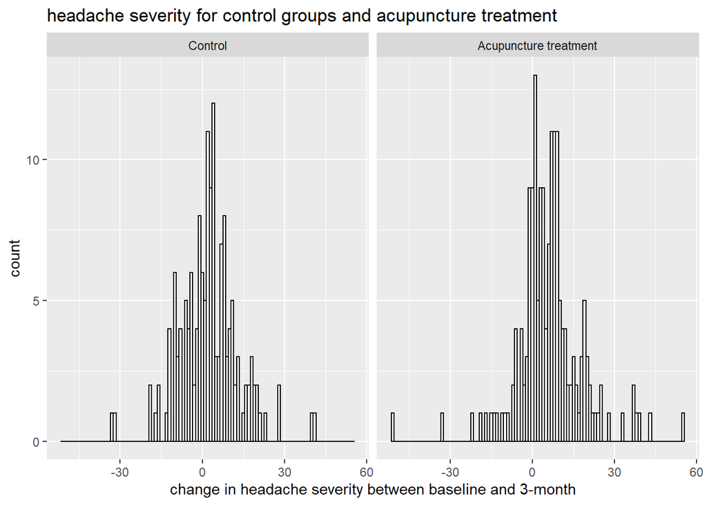

```r
ggplot(acudata, aes(x=change_pk1_pk2))+
  geom_histogram(binwidth = 1, color="black", fill="white") +
  ggtitle("headache severity for control groups and acupuncture treatment")+
  xlab("change in headache severity between baseline and 3-month")+
  facet_wrap(~con_acu_group)
```

```r
acudata %>% drop_na(change_pk1_pk2) %>% group_by(con_acu_group) %>%
  summarize(n = n(),
            mean = mean(change_pk1_pk2),
            SD = sd(change_pk1_pk2),
            median = median(change_pk1_pk2),
            IQR = IQR(change_pk1_pk2),
            min = min(change_pk1_pk2),
            max = max(change_pk1_pk2))
```

| con_acu_group | n | mean | SD | median | IQR | min | max |
| --- | --- | --- | --- | --- | --- | --- | --- |
| Control | 153 | 2.748366 | 10.83607 | 2.75 | 11.75 | -32.75 | 40.75 |
| Acupuncture treatment | 173 | 6.453757 | 12.22871 | 6.00 | 10.25 | -50.75 | 55.50 |

From the distribution of the change in headache severity separately for the acupuncture treatment and control groups, we can find that the distribution of control is more likely be bell-shaped compared to acupuncture treatment. The medians of two distributions are roughly locate in 2.75 and 6.

## Two-sample t test

```r
#0.05 significance level

#H_0: (u_control-u_acupuncture equal 0) difference in headache severity (from baseline to 3 months) by control group and acupuncture treatment is zero.
#H_1: (u_control-u_acupunct ure not equal 0)difference in headache severity (from baseline to 3 months) by control group and acupuncture treatment is not zero.

#conditions: simple random sample, 2 independent groups, and number of two group > 30.

t.test(change_pk1_pk2 ~ con_acu_group, data = acudata,
       alternative = "two.sided",
       conf.level = 0.95)
```

```
##
##  Welch Two Sample t-test
##
## data:  change_pk1_pk2 by con_acu_group
## t = -2.9006, df = 324, p-value = 0.003979
## alternative hypothesis: true difference in means between group Control and group Acupuncture treatment is not equal to 0
## 95 percent confidence interval:
##  -6.218516 -1.192266
## sample estimates:
##               mean in group Control mean in group Acupuncture treatment
##                            2.748366                            6.453757
```

```r
#the value of the test statistic from this sample
-2.9006
```

```
## [1] -2.9006
```

```r
#the p-value
0.003979
```

```
## [1] 0.003979
```

```r
#reject H0 (p-value < significance level)

#We have strong evidence that the true mean change in headache severity between control group and acupuncture treatment is not 0.

#we have 95% confident interval that headache severity by control group is less 1.192266 to 6.218516 on average than acupuncture treatment group.
```

## Wilcoxon rank sum test

```r
# 0.05 significance level

#H0: the population median from group Control equal the population median from acupuncture treatment.
#H1: the population median from group Control is not equal the population median from acupuncture treatment.
#Conditions: simple random samples from two populations and independent groups

wilcox.test(change_pk1_pk2 ~ con_acu_group, data = acudata,
       alternative = "two.sided",
       conf.level = 0.95,
       correct = FALSE)
```

```
##
##  Wilcoxon rank sum test
##
## data:  change_pk1_pk2 by con_acu_group
## W = 10483, p-value = 0.001195
## alternative hypothesis: true location shift is not equal to 0
```

```r
#the p-value
0.001195
```

```
## [1] 0.001195
```

```r
#reject H0 (p-value < significance level)

#We have strong evidence that the the population median from group Control is not equal the population median from acupuncture treatment.
```

## Summary of part 2

From the part 2, we can find that change in headache severity for between the acupuncture treatment and control groups is not 0. Acupuncture treatment on headache severity (from baseline to 3 months) is more 1.192266 to 6.218516 on average efficient than control group. By Two-sample t test, and the population median from group Control is not equal the population median from acupuncture treatment by Wilcoxon rank sum test.